# Analyse WES CNR

2023-06-07

# 1 Background

The main aim of the project is to determine the clinical utility of a risk score algorithm based on Copy Number Variation (CNV) in liquid and solid biopsy data.

Our primary patient cohorts are from the PROMOTE (**P**rostate Cancer **M**edically-**O**p**t**imized Genome-Enhanced **T**h**e**rapy) study, which contains liquid and solid tissue biopsies.

All patients undergo two serial metastatic tissue or bone biopsies, with the first biopsy performed prior to the initiation of AA/P treatment (visit 1: pretreatment) and the second after 12 weeks of treatment (visit 2: posttreatment). We want to determine. concordance in both the vists.

We will limit our analysis to the 11 genes described in the [paper](https://www.mdpi.com/2072-6694/14/19/4714) as having a good prognostic risk score to determine survival.

In this part of analysis, we extract clinical data from various papers, and simplify the copy number calls provdied by [David Nix](https://uofuhealth.utah.edu/staff/david-nix).

# 2 Objectives

1. Read clinical data into R
2. Read exome data CNA results
3. Set trehsold of CNA
4. Comparison to public dataset
5. Correlation of CNV with ctDNA & tumor purity

# 3 Pre-processing

## 3.1 Loading packages

```r
library(here)
library(tidyverse)
library(ggplot2)
library(readxl)
library(reshape2)
library(ComplexHeatmap)
library(ggbeeswarm)
library(patchwork)
library(ggpubr)

library(survival)
library(ggsurvfit)
library(survminer)
library(eulerr)

library(ggrain)
devtools::source_url("https://raw.githubusercontent.com/yjunechoe/geom_paired_raincloud/master/geom_paired_raincloud.R")
```

## 3.2 Directories

```r
wd <- list()
wd$main <- here()
wd$data <- file.path(wd$main, "data")
wd$dataP <- file.path(wd$data, "processed")
wd$output <- file.path(wd$main, "output")
wd$script <- file.path(wd$main, "scripts")
wd$outputData <- file.path(wd$output, "out_data")

# Supplemental data from previous publications
wd$papers <- file.path(wd$data, "from_papers")
```

Create directories

```r
# List of all directories
directories <- list(wd$main, wd$data, wd$dataP, wd$output, wd$script, wd$outputData)

# Create directories if they don't exist
for (dir in directories) {
  if (!file.exists(dir)) {
    dir.create(dir, recursive = TRUE)
  } else {
    print(paste("Directory already exists:", dir))
  }
}
```

```
## [1] "Directory already exists: /Users/zakiwilmot/Library/CloudStorage/Box-Box/Projects/ZW_010_ProstatePROMOTE"
## [1] "Directory already exists: /Users/zakiwilmot/Library/CloudStorage/Box-Box/Projects/ZW_010_ProstatePROMOTE/data"
## [1] "Directory already exists: /Users/zakiwilmot/Library/CloudStorage/Box-Box/Projects/ZW_010_ProstatePROMOTE/data/processed"
## [1] "Directory already exists: /Users/zakiwilmot/Library/CloudStorage/Box-Box/Projects/ZW_010_ProstatePROMOTE/output"
## [1] "Directory already exists: /Users/zakiwilmot/Library/CloudStorage/Box-Box/Projects/ZW_010_ProstatePROMOTE/scripts"
## [1] "Directory already exists: /Users/zakiwilmot/Library/CloudStorage/Box-Box/Projects/ZW_010_ProstatePROMOTE/output/out_data"
```

Read the 11 gene panel we are interested in

```r
df_gene <- read.delim(file.path(wd$data, "gene_panel.txt"))
gene_panel <- df_gene %>% pull(Genes)
```

# 4 Objective 1

**Read metadata into R**

There are few data that we want to read into R ;

## 4.1 Liquid results

We read the file linking the exome sampleID with the Manish paper’s ID. First read the PatientID based on the paper.

```r
file_dir <- file.path(wd$data, "from_papers/cancers_2022_plasma/")
df_link <- readxl::read_excel(file.path(file_dir, "Table S3.xlsx"),
                              sheet = 4) %>%
  mutate(SubjectID = toupper(SubjectID))
```

Next read the copy number results. Limit to the 11 genes of interest

```r
# Visit 1
file_dir <- file.path(wd$data, "from_papers/cancers_2022_plasma/")
pap_v1 <- readxl::read_excel(file.path(file_dir, "Table S3.xlsx"),
                              sheet = 2)  %>%
  rename(PatientID = PatientID...1) %>%
  select(PatientID, AR, COL22A1, MYC, NCOR1, NKX3.1, NOTCH1, PIK3CA, PIK3CB, TP53, ZBTB16, TMPRSS2) %>%
  mutate(across(AR:TMPRSS2, ~ case_when(
    . == "NC" ~ 0,
    . == "Amp" ~ 1,
    . == "Del" ~ -1))) %>% as.data.frame()
# Repeat for visit 2
pap_v2 <- readxl::read_excel(file.path(file_dir, "Table S3.xlsx"),
                              sheet = 3)  %>%
  rename(PatientID = PatientID...1) %>%
  select(PatientID, AR, COL22A1, MYC, NCOR1, NKX3.1, NOTCH1, PIK3CA, PIK3CB, TP53, ZBTB16, TMPRSS2) %>%
  mutate(across(AR:TMPRSS2, ~ case_when(
    . == "NC" ~ 0,
    . == "Amp" ~ 1,
    . == "Del" ~ -1))) %>% as.data.frame()
```

Get the number of patient from each visit

```r
length(unique(pap_v1$PatientID))
```

```
## [1] 87
```

```r
length(unique(pap_v2$PatientID))
```

```
## [1] 83
```

## 4.2 Liquid metadata

We are interested in the ctDNA content of the liquid samples. This information is provided from this [paper](https://www.nature.com/articles/s41391-020-0224-4). We read the data.

We asked Liang how to consolidate the sample names from differnt papers.

> the P1 is equal to MJ1. P is always odd number because each patient has two plasma samples (MJ1 and MJ2 are from the same patient P1)

```r
meta_l <- readxl::read_excel(file.path(wd$papers, "ProstateCancer_2020/Supplementary Tables.xlsx"),
                               sheet = 1,
                              skip = 1)
# Some renaming
meta_l <- meta_l %>%
  rename(ID_V1 = 'Plasma ID...2',
         ID_V2 = 'Plasma ID...4',
         ctDNA_V1 = 'ctDNA Content  (V1:  Pre-treatment)',
         ctDNA_V2 = 'ctDNA Content (V2: Post-treatment)') %>%
  select(ID_V1, ID_V2, ctDNA_V1, ctDNA_V2) %>%
  mutate(ID_V1 = paste0("MJ", ID_V1),
         ID_V2 = paste0("MJ", ID_V2))

# Convert to long format
meta_l <- data.frame(
  PatientID = c(meta_l$ID_V1, meta_l$ID_V2),
  ctDNA = c(meta_l$ctDNA_V1, meta_l$ctDNA_V2)
) %>%
  mutate(ctDNA = as.numeric(ctDNA) * 100)

# Add other info
meta_l <- full_join(meta_l, df_link)
```

## 4.3 Exome metadata

We will read the metadata for the exome solid tumors from [visit 1](https://pubmed.ncbi.nlm.nih.gov/29069303/) and [visit 2](https://pubmed.ncbi.nlm.nih.gov/36135372/). The metadata are in supplemental tables of the papers.

Lets extract the PatientID, progression status and sample source (bone, non-bone), tumor content.

```r
# Some samples metadata is missing from annal Onco paper. For example S78 data is missing from annal Onco paper. S

# meta_v1 <- readxl::read_excel(file.path(wd$papers, "visit_1_annalOnco_2016/Suppl_TabS1-S16_mdx689.xlsx"),
#                                sheet = 1,
#                               skip = 1)
# meta_v1 <- meta_v1 %>%
#   rename(SubjectID = Subject_ID,
#          Comp_prog =  'Composite\r\nProgression',
#          Sample_type = Sample_Type,
#          Tumor_content = 'Tumor\r\ncontent') %>%
#   select(SubjectID, Comp_prog, Sample_type, Tumor_content) %>%
#   mutate(SubjectID = paste0("S", SubjectID),
#          Tumor_content = as.numeric(Tumor_content),
#          Tumor_content = Tumor_content* 100,
#          Sample_type = case_when(Sample_type == "Bone" ~ "Bone",
#                                  TRUE ~ "non-bone")) %>%
#   select(-Tumor_content) %>%
#   na.omit()


# We take meta data from another paper
meta_v1 <- readxl::read_excel(file.path(wd$papers, "visit_2_molCanRes_2022/mcr-22-0099_supplementary_tables_1-41_suppst1-41.xlsx"),
                               sheet = 3,
                              skip = 1) %>%
  filter(Visit == "V1") %>%
  rename(SubjectID = SampleID_withdBGapPatient,
         Sample_type = Tissue,
         Tumor_content = CNPurity) %>%
  select(SubjectID, Sample_type, Tumor_content) %>%
  mutate(SubjectID = gsub("_.*", "", SubjectID),
         SubjectID = paste0("S", SubjectID),
         Tumor_content = Tumor_content * 100,
         Sample_type = case_when(Sample_type == "Bone" ~ "Bone",
                                 TRUE ~ "non-bone")) #%>%
  #select(SubjectID, Tumor_content)

#meta_v1 <- meta_v1 %>% left_join(meta_v1_p2)
```

Repeat for visit 2. The data for visit 2 is a bit messy, the information are located in different excel sheets.

```r
# Get the sample type
meta_v2_p1 <- readxl::read_excel(file.path(wd$papers, "visit_2_molCanRes_2022/mcr-22-0099_supplementary_tables_1-41_suppst1-41.xlsx"),
                               sheet = 3,
                              skip = 1) %>%
  filter(Visit == "V2") %>%
  rename(SubjectID = SampleID_withdBGapPatient,
         Sample_type = Tissue,
         Tumor_content = CNPurity) %>%
  select(SubjectID, Sample_type, Tumor_content) %>%
  mutate(SubjectID = gsub("_.*", "", SubjectID),
         SubjectID = paste0("S", SubjectID),
         Tumor_content = Tumor_content * 100)

# Get the progression
meta_v2_p2 <- readxl::read_excel(file.path(wd$papers, "visit_2_molCanRes_2022/mcr-22-0099_supplementary_tables_1-41_suppst1-41.xlsx"),
                               sheet = 1,
                              skip = 1) %>%
  rename(SubjectID = dbGAP_ID,
         Comp_prog = Composite_Progression_3_mo) %>%
  select(SubjectID, Comp_prog) %>%
  mutate(Comp_prog = case_when(Comp_prog == "Yes" ~ 1,
                                Comp_prog == "-Yes" ~ 1,
                              Comp_prog == "No" ~ 0,
                              Comp_prog == "N/A" ~ -1,
                              Comp_prog == "NA" ~ -1),
         SubjectID = paste0("S", SubjectID))

# # Get the tumor percentage
# meta_v2_p3 <- readxl::read_excel(file.path(wd$papers, "visit_2_molCanRes_2022/mcr-22-0099_supplementary_tables_1-41_suppst1-41.xlsx"),
#                                sheet = 4,
#                               skip = 1) %>%
#   mutate(visit = gsub(".*_", "", RNASeqSample),
#          visit = gsub("N|T", "", visit)) %>%
#   filter(visit == "V2") %>%
#     rename(SubjectID = RNASeqSample,
#          Tumor_content = PURITY) %>%
#     select(SubjectID, Tumor_content) %>%
#     mutate(SubjectID = gsub("_.*", "", SubjectID),
#            SubjectID = paste0("S", SubjectID),
#            Tumor_content = as.numeric(Tumor_content),
#            Tumor_content = Tumor_content* 100)

# Merge metadata for V2
meta_v2 <- meta_v2_p1 %>% full_join(meta_v2_p2) %>% distinct() %>%
  select(SubjectID, Comp_prog, Sample_type, Tumor_content) %>%
  mutate(Sample_type = case_when(Sample_type == "Bone" ~ "Bone",
                                 TRUE ~ "non-bone"))
```

## 4.4 Exome CNR resuls

Now read the sample ID from David Nix analysis.

```r
file_dir <- file.path(wd$data, "from_DavidNix")
df_link2 <- readxl::read_excel(file.path(file_dir, "sra_metadata_398SampleSets.xlsx"),
                               sheet = 3)
# Select relevant columns
df_link2_full <- df_link2 %>% select(SampleName, Subject_ID, Run, Analyte_Type, Body_Site) %>%
  rename(
    Exome_ID = Subject_ID,
    SubjectID = SampleName,
    lib_type = Analyte_Type) %>%
  # Modify the Subject ID to only contain the sample name
  mutate(visit = gsub(".*DNA_|.*RNA_", "", SubjectID),
         visit = gsub("N|B|T", "", visit),
         SubjectID = gsub("_.*", "", SubjectID)
         )

df_link2 <- df_link2_full %>%
  # Select only the DNA, not interested in RNA
  filter(lib_type == "DNA")
```

Retain to only the samples we have from the paper

```r
tt <- df_link %>%
  mutate(
    tmp = case_when(Type == "Promote1" ~ "V1",
                    Type == "Promote2" ~ "V2"),
    UniqID = paste(SubjectID, tmp, sep="_")) %>%
  select(UniqID, PatientID)

df_link2 <- df_link2 %>%
  mutate(UniqID = paste(SubjectID, visit, sep="_")) %>%
  filter(SubjectID %in% df_link$SubjectID) %>%
  left_join(tt)
```

## 4.5 Sample overview

Lets get the number of samples (PatientID from Vist 1 and Visit 2)

```r
# Get the number of patient with tumor samples regardless of site
df_link2 %>% filter(visit == "V1" & !Body_Site == "Blood") %>% pull(PatientID) %>% unique() %>% length()
```

```
## [1] 72
```

```r
df_link2 %>% filter(visit == "V2" & !Body_Site == "Blood") %>% pull(PatientID) %>% unique() %>% length()
```

```
## [1] 75
```

### 4.5.1 Exome summary

Summary of available samples

```r
# Exome data
# Samples with blood (ie - matching normal)
d1 <- df_link2 %>% filter(Body_Site == "Blood") %>% select(SubjectID, Exome_ID, Run) %>%
  rename(Germline_RunID = Run)

d2 <- df_link2 %>% filter(!Body_Site == "Blood" & visit == "V1") %>% select(SubjectID, visit, Body_Site, Exome_ID, Run) %>%
  rename(Visit_1 = visit,
         #Visit_1_ID = PatientID,
         Visit_1_Site = Body_Site,
         Visit_1_ExomeID = Exome_ID,
         Visit_1_RunID = Run)
d3 <- df_link2 %>% filter(!Body_Site == "Blood" & visit == "V2") %>% select(SubjectID, visit, Body_Site, Exome_ID, Run) %>%
  rename(Visit_2 = visit,
         #Visit_2_ID = PatientID,
         Visit_2_Site = Body_Site,
         Visit_2_ExomeID = Exome_ID,
         Visit_2_RunID = Run)

# # Add Site
# d_tmp <- df_link2 %>% select(SubjectID, Body_Site) %>% filter(!Body_Site == "Blood") %>% distinct()
#
d_all <- d1 %>% left_join(d2) %>% left_join(d3)
#

# Add Unique Patient ID for visit 1 and visit 2
id_1 <- meta_l %>% filter(Type == "Promote1") %>% select(SubjectID, PatientID) %>%
  rename(Visit_1_ID = PatientID) %>% distinct()
id_2 <- meta_l %>% filter(Type == "Promote2") %>% select(SubjectID, PatientID) %>%
  rename(Visit_2_ID = PatientID) %>% distinct()

d_all <- d_all %>% left_join(id_1) %>% left_join(id_2)
```

### 4.5.2 Liquid summary

Add liquid samples to the data frame

```r
dd <- df_link %>%
  mutate(Type =
           case_when(Type == "Promote1" ~ "V1",
                    Type == "Promote2" ~ "V2"))
d1 <- dd %>% filter(Type == "V1") %>% select(SubjectID, Type) %>%
    rename(l_Visit_1 = Type)
d2 <- dd %>% filter(Type == "V2") %>% select(SubjectID, Type) %>%
    rename(l_Visit_2 = Type)

dl <- full_join(d1,d2)
d_all <- full_join(d_all, dl)
```

Mark if the sample is present in the liquid

Save the file

```r
writexl::write_xlsx(d_all, file.path(wd$output, "SampleSummary_2_ori.xlsx"))
```

Add the tumor purity information for visit 1

```r
meta_v1_sub <- meta_v1 %>% select(SubjectID, Tumor_content)
d_all2 <- d_all %>% left_join(meta_v1_sub)
# For visit 2
meta_v2_sub <- meta_v2 %>% select(SubjectID, Tumor_content) %>%
  rename(Tumor_content_v2 = Tumor_content)
d_all2 <- d_all2 %>% left_join(meta_v2_sub)
writexl::write_xlsx(d_all2, file.path(wd$output, "SampleSummary_2_ori.xlsx"))
```

## 4.6 Sample numbers

We create a Venn diagram to overlap the sample numbers between solid and liquid per-visit.

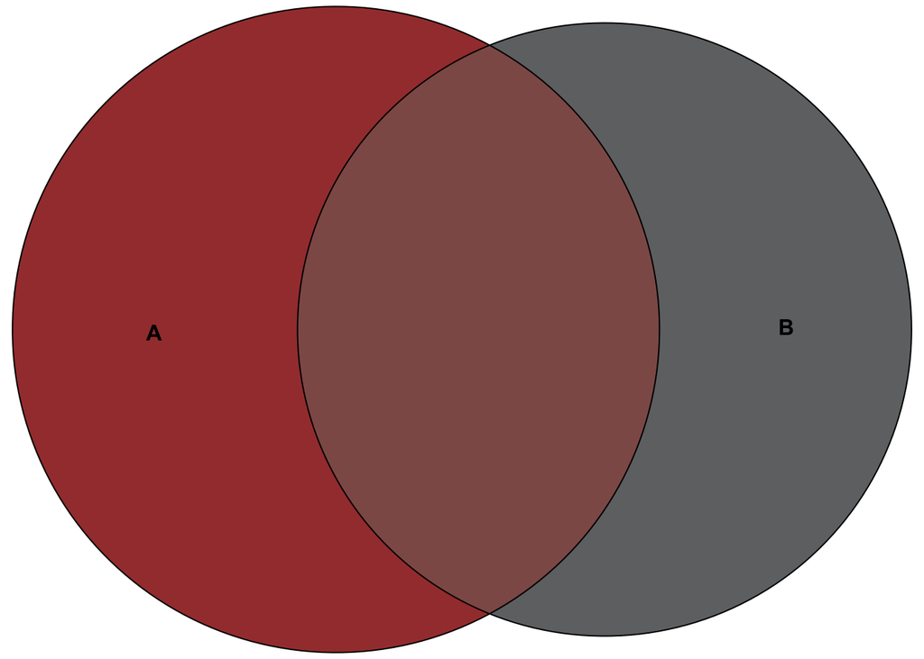

```r
# Liquid patient id - same across visit 1 and visit 2
n_l <- 83

# Visit 1 solid patient that pass QC
s1 <- 68
s2 <- 74

# Overlap in each category (we did manually by venny based on supplemental table 2)
o1 <- 68
o2 <- 74
# Specify values to use in venn diagram
fit_v1 <- euler(c('A' = 83, 'B' = 68, 'A&B' = 68))
fit_v2 <- euler(c('A' = 83, 'B' = 74, 'A&B' = 74))

plot(fit_v1, fill=c('#A53D3C', '#6F7173'))
```

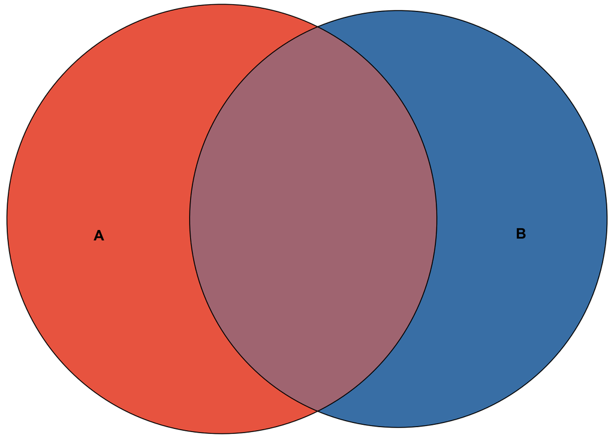

```r
plot(fit_v2, fill=c('coral2', 'steelblue'))
```

```r
#create venn diagram with custom colors
pdf(file.path(wd$output, "Solid_liquid_venn.pdf"), width = 7, height = 4)
plot(fit_v1, fill=c('#A53D3C', '#6F7173'))
plot(fit_v2, fill=c('coral2', 'steelblue'))
dev.off()
```

## 4.7 Exome copy results

Lets read the folder names containing the copy results

```r
file_dir <- file.path(wd$data, "from_DavidNix/CNR_exome_analysis/pass_QC")
gg <- list.files(file_dir)
```

Sample name & the RUN ID is sperated by ‘*’ ,so separate the study arms based on the ’*’ separator. Then extarct the Sample name and Run ID

```r
list_split <- str_split(gg, "_")
names(list_split) <- gg

# Extract the Sample Name [2], Run ID [3]
# https://stackoverflow.com/questions/38436872/get-access-to-the-first-row-of-a-list-in-r
#s_name <- sapply(list_split,'[[',2)
df_exome_pass <- sapply(list_split,`[`,c(2,3)) %>% t() %>% as.data.frame() %>%
  # Rename column
  dplyr::rename(Exome_ID_tmp = V1,
                Run = V2) %>%
  mutate(filter = "pass",
         file_name = gg)

# Retain only the samples in the paper
df_exome_pass <- df_exome_pass %>% filter(Run %in% df_link2$Run)

length(unique(df_exome_pass$Exome_ID_tmp))
```

```
## [1] 82
```

Repeat for the failed

```r
file_dir <- file.path(wd$data, "from_DavidNix/CNR_exome_analysis/fail_QC")
gg <- list.files(file_dir)


list_split <- str_split(gg, "_")
names(list_split) <- gg

# Extract the Sample Name [2], Run ID [3]
# https://stackoverflow.com/questions/38436872/get-access-to-the-first-row-of-a-list-in-r
#s_name <- sapply(list_split,'[[',2)
df_exome_fail <- sapply(list_split,`[`,c(2,3)) %>% t() %>% as.data.frame() %>%
  # Rename column
  dplyr::rename(Exome_ID_tmp = V1,
                Run = V2)  %>%
  mutate(filter = "fail",
         file_name = gg)

# Retain only the samples in the paper
df_exome_fail <- df_exome_fail %>% filter(Run %in% df_link2$Run)

length(unique(df_exome_fail$Exome_ID_tmp))
```

```
## [1] 5
```

Merge the two

```r
df_exome <- rbind(df_exome_pass, df_exome_fail) %>%
  rename(Exome_ID = Exome_ID_tmp)
rownames(df_exome) <- NULL
```

We know that visit 1 starts with ‘Nci’ and visit 2 starts with ‘Mayo’.

```r
df_exome <- df_exome %>%
  mutate(Visit = gsub("Nci_.*", "V1", file_name),
         Visit = gsub("Mayo_.*", "V2", Visit),
         UniqID = paste(Exome_ID, Visit, sep="_")) %>%
  select(-Visit, -Exome_ID, -Run)
```

Join with the master file

```r
df_link2_noBlood <- df_link2 %>% filter(!Body_Site == "Blood") %>%
    mutate(Exome_ID = as.character(Exome_ID),
         UniqID = paste(Exome_ID, visit, sep="_"))

df_join <- df_link2_noBlood %>%
  left_join(df_exome)
```

Check sample numbers

```r
# Get the number of patient regardless of site
df_join %>% filter(visit == "V1") %>% pull(PatientID) %>% unique() %>% length()
```

```
## [1] 72
```

```r
df_join %>% filter(visit == "V2") %>% pull(PatientID) %>% unique() %>% length()
```

```
## [1] 75
```

How to deal with samples that failed QC.

Exclude **samples** from further analysis (ie, only remove the visit that failed)

```r
df_join2 <- df_join %>% filter(!filter == "fail")

df_join2 %>% filter(visit == "V1") %>% pull(PatientID) %>% unique() %>% length()
```

```
## [1] 68
```

```r
df_join2 %>% filter(visit == "V2") %>% pull(PatientID) %>% unique() %>% length()
```

```
## [1] 74
```

Get some summary of the number of patients with measurement at both time-point or just one time point

```r
tt <- table(df_join2$SubjectID, df_join2$visit)

# Both visit
sum(rowSums(tt) >= 2)
```

```
## [1] 60
```

```r
# Visit 1
sum(tt[,1] >=1 )
```

```
## [1] 68
```

```r
# Visit 2
sum(tt[,2] >=1 )
```

```
## [1] 74
```

## 4.8 Add exome metadata

Add if the exome pass or fail QC

```r
t1 <- df_join %>% filter(visit == "V1") %>% select(SubjectID, filter) %>% distinct() %>%
  rename(QC_V1 = filter)
t2 <- df_join %>% filter(visit == "V2") %>% select(SubjectID, filter) %>% distinct() %>%
  rename(QC_V2 = filter)

d_all2 <- d_all2 %>% left_join(t1) %>% left_join(t2)
writexl::write_xlsx(d_all2, file.path(wd$output, "SampleSummary_2_ori.xlsx"))
```

Add the ctDNA (liquid) concentration

```r
meta_l_v1 <- meta_l %>% filter(Type == "Promote1") %>%
  select(SubjectID, ctDNA, PatientID) %>%
  rename(ctDNA_v1 = ctDNA,
         Patient_ID_l_v1 = PatientID)

meta_l_v2 <- meta_l %>% filter(Type == "Promote2") %>%
  select(SubjectID, ctDNA, PatientID) %>%
  rename(ctDNA_v2 = ctDNA,
         Patient_ID_l_v2 = PatientID)

d_all3 <- d_all2 %>% left_join(meta_l_v1)
d_all3 <- d_all3 %>% left_join(meta_l_v2)
writexl::write_xlsx(d_all3, file.path(wd$output, "SampleSummary_2_ori.xlsx"))
```

## 4.9 Add survial data

Add metadata on survival an OS

```r
file_dir <- file.path(wd$data, "from_papers/cancers_2022_plasma/")
# Visit 1
os_v1 <- readxl::read_excel(file.path(file_dir, "Corrected_Table_S3.xlsx"),
                              sheet = 2) %>%
  select(PatientID...26:Progression) %>%
  rename(PatientID = PatientID...26,
         Death = 'Death (0-no death event)',
         OS = 'OS (Days)',
         Res = 'Response at 3-months; 0=no response (corrected)',
         PFS = 'PFS (Days)',
         Prog = Progression) %>%
  # Convert to month
  # divide by the average day by month.
  mutate(OS = round(OS/30.417, digit=2),
         PFS = round(PFS/30.417, digit=2))
# Visit 2
os_v2 <- readxl::read_excel(file.path(file_dir, "Corrected_Table_S3.xlsx"),
                              sheet = 3) %>%
  select(PatientID...26:Progression) %>%
  rename(PatientID = PatientID...26,
         Death = 'Death (0-no death event)',
         OS = 'OS (Days)',
         Res = 'Response at 3-months; 0=no response (corrected)',
         PFS = 'PFS (Days)',
         Prog = Progression) %>%
  # Convert to month
  # divide by the average day by month.
  mutate(OS = round(OS/30.417, digit=2),
         PFS = round(PFS/30.417, digit=2))
```

Now lets generate a table of the survival metadata along with ctDNA content, tumor content.

```r
d_all3_sub <- d_all3 %>%
  select(SubjectID, l_Visit_1, l_Visit_2, Visit_1_Site, Visit_2_Site, ctDNA_v1, ctDNA_v2, Tumor_content, Tumor_content_v2,
         Visit_1_ID, Visit_2_ID, QC_V1, QC_V2
)

# We want each visit ID in a row
d1_v1 <- left_join(d_all3_sub, os_v1, by = c("Visit_1_ID" = "PatientID"))
d1_v2 <- left_join(d_all3_sub, os_v2, by = c("Visit_2_ID" = "PatientID"))

d_v <- rbind(d1_v1, d1_v2)

writexl::write_xlsx(d_v, file.path(wd$output, "SampleSummary_3_ori.xlsx"))
```

## 4.10 DNA purity by site

Lets look at the DNA purity in all samples, by site.

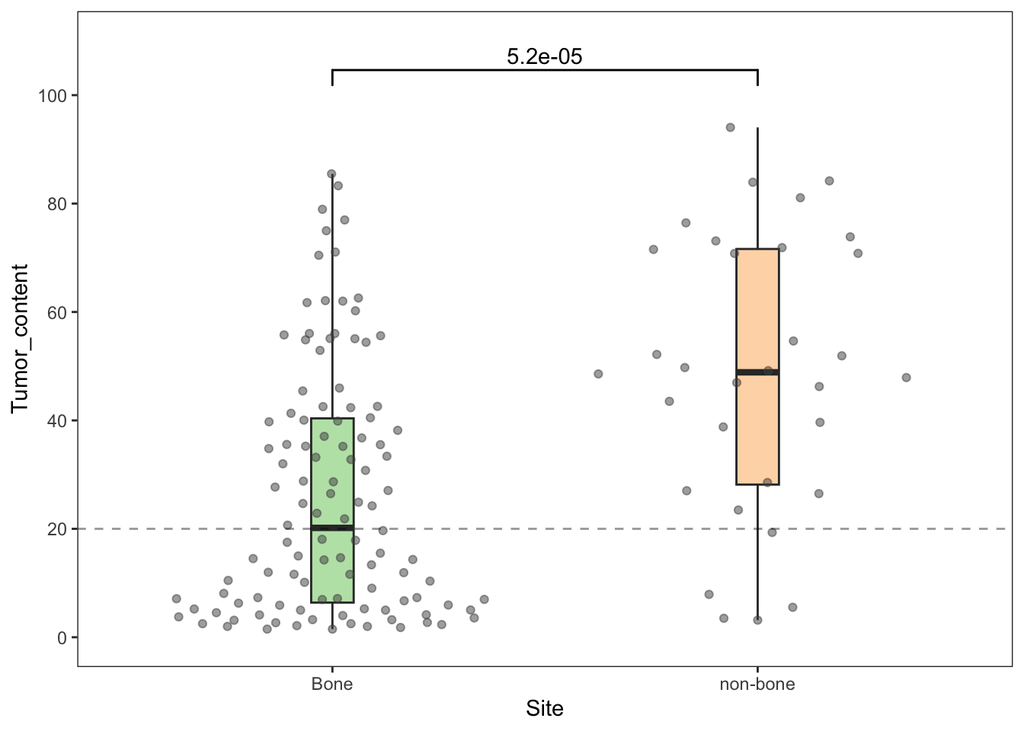

```r
# Generate df with the purity
d1 <- d_v %>% select(Visit_1_ID, Tumor_content, Visit_1_Site) %>%
  rename(Site = Visit_1_Site,
         PatientID = Visit_1_ID) %>% distinct() %>%
  mutate(Visit = "V1")
d2 <- d_v %>% select(Visit_2_ID, Tumor_content_v2, Visit_2_Site) %>%
  rename(Site = Visit_2_Site,
         Tumor_content = Tumor_content_v2,
         PatientID = Visit_2_ID) %>% distinct() %>%
  mutate(Visit = "V2")

df_tumor_p <- rbind(d1, d2) %>% filter(!is.na(Site)) %>%
  mutate(Site = case_when(Site == "bone" ~ "Bone",
                          TRUE ~ "non-bone"),
         Purity = case_when(Tumor_content <=20 ~ "Low",
                            Tumor_content >20 ~ "High"))

# Filter to those that pass exome QC
# visit 1 that pass QC
v1_pass <- d_all2 %>% filter(QC_V1 == "pass")
t1 <- df_tumor_p %>% filter(PatientID %in% v1_pass$Visit_1_ID & Visit == "V1")

# visit 2 that pass QC
v2_pass <- d_all2 %>% filter(QC_V2 == "pass")
t2 <- df_tumor_p %>% filter(PatientID %in% v2_pass$Visit_2_ID & Visit == "V2")

df_tumor_p2 <- df_tumor_p %>% filter(PatientID %in% c(t1$PatientID, t2$PatientID))

ggplot(df_tumor_p2, aes(x=Site, y=Tumor_content, fill=Site)) +
  geom_boxplot(outlier.alpha = 0,  width = 0.1, fatten=3, alpha=0.6,
               position = position_dodge(width = 0.9)) +
  geom_quasirandom(dodge.width=0.05, colour="grey30", alpha=0.5) +
  theme_bw() +
  theme(legend.position = "none",
          panel.grid.major = element_line(linetype = "blank"),
          panel.grid.minor = element_line(linetype = "blank")) +
  scale_fill_manual(values=c("#8CD17D", "#FFBE7D")) +
  geom_signif(
    comparisons = list(
      c("Bone", "non-bone")),
    map_signif_level = FALSE, test = "t.test",
    y_position=100) +
  geom_hline(yintercept = 20, linetype="dashed", alpha=0.4) +
  scale_y_continuous(limits=c(0,110), breaks=c(0,20,40,60,80, 100)) +
  NULL
```

```r
ggsave(file=file.path(wd$output, "cDNA_bone_vs_no_all.pdf"), device = "pdf", width = 4, height = 4)

table(df_tumor_p$Site, df_tumor_p$Purity)
```

```
##
##            High Low
##   Bone       56  58
##   non-bone   28   5
```

For the same samples let get the liquid tumor ctDNA values

```r
# Generate df with the ctDNA
d1 <- d_v %>% select(Visit_1_ID, ctDNA_v1) %>%
  rename(PatientID = Visit_1_ID,
         ctDNA = ctDNA_v1) %>% distinct()

d2 <- d_v %>% select(Visit_2_ID, ctDNA_v2) %>%
  rename(PatientID = Visit_2_ID,
         ctDNA = ctDNA_v2) %>% distinct()

df_tumor_ctDNA <- rbind(d1, d2)

# Join with the plot
df_tumor_p3 <- df_tumor_p2 %>% left_join(df_tumor_ctDNA)
```

Plot as histogram

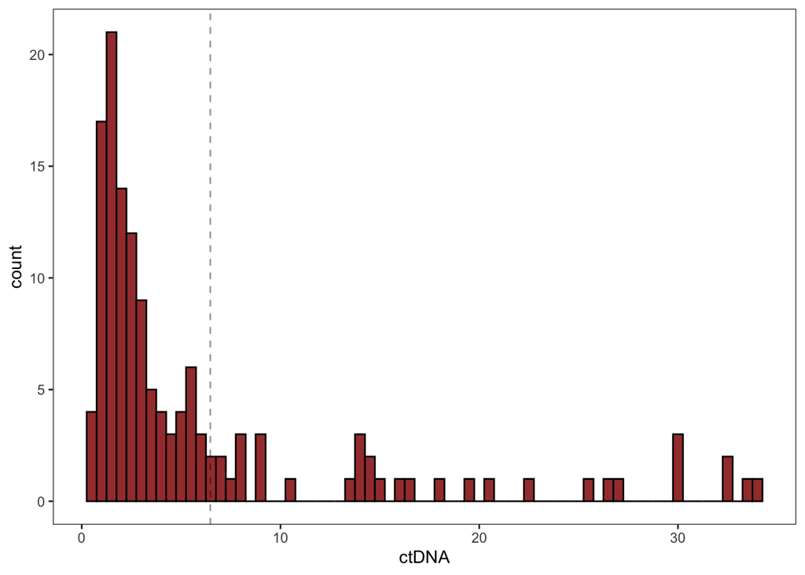

```r
ct_vals <- summary(df_tumor_p3$ctDNA)
ct_cutoff <- ct_vals[5] # 3 is the median, 5 is the 3rd quartile
p_hist <-
  ggplot(df_tumor_p3, aes(x=ctDNA)) +
  geom_histogram(binwidth=0.5, color="black", fill="#A53D3C") +
    theme_bw() +
  theme(legend.position = "none",
          panel.grid.major = element_line(linetype = "blank"),
          panel.grid.minor = element_line(linetype = "blank")) +
  geom_vline(xintercept = ct_cutoff, linetype="dashed", alpha=0.4) +
  NULL

p_hist
```

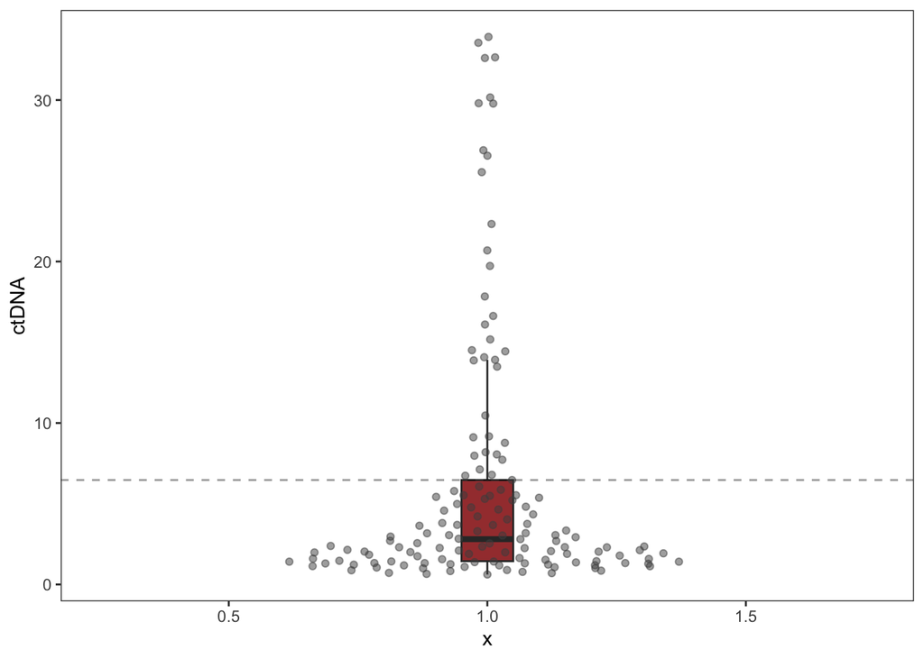

```r
ggsave(p_hist, file=file.path(wd$output, "ctDNA.pdf"), device = "pdf", width = 7, height = 4.5)
# As a box-plot format
p_box <-
  ggplot(df_tumor_p3, aes(x=1, y=ctDNA, fill="x")) +
  geom_boxplot(outlier.alpha = 0,  width = 0.1, fatten=3, alpha=1,
               position = position_dodge(width = 0.9)) +
  geom_quasirandom(dodge.width=1.5, colour="grey30", alpha=0.5) +
  theme_bw() +
  theme(legend.position = "none",
        panel.grid.major = element_line(linetype = "blank"),
        panel.grid.minor = element_line(linetype = "blank")) +
  scale_fill_manual(values=c("#A53D3C")) +
  geom_hline(yintercept = ct_cutoff, linetype="dashed", alpha=0.4) +
  #scale_y_continuous(limits=c(0,110), breaks=c(0,20,40,60,80, 100)) +
  NULL
p_box
```

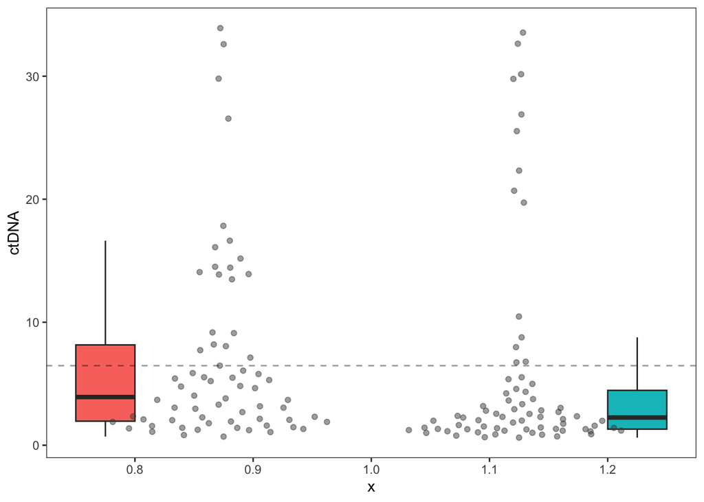

```r
ggsave(p_box, file=file.path(wd$output, "ctDNA_boxPlot.pdf"), device = "pdf", width = 5, height = 4.5)
# Just for refernce, plot the V1 and V2 side by side
p_box2 <-
  ggplot(df_tumor_p3, aes(x=1, y=ctDNA, fill=Visit)) +
  geom_boxplot(outlier.alpha = 0,  width = 0.1, fatten=3, alpha=1,
               position = position_dodge(width = 0.9)) +
  geom_quasirandom(dodge.width=0.5, colour="grey30", alpha=0.5) +
  theme_bw() +
  theme(legend.position = "none",
        panel.grid.major = element_line(linetype = "blank"),
        panel.grid.minor = element_line(linetype = "blank")) +
  #scale_fill_manual(values=c("#A53D3C")) +
  geom_hline(yintercept = ct_cutoff, linetype="dashed", alpha=0.4) +
  #scale_y_continuous(limits=c(0,110), breaks=c(0,20,40,60,80, 100)) +
  NULL
p_box2
```

```r
# Cut-off ot x
df_tumor_p3 <- df_tumor_p3 %>% mutate(ct_cut =
                                        case_when(ctDNA <=ct_cutoff ~ "Low",
                                                  ctDNA >ct_cutoff ~ "High"))
```

Get number of samples

```r
table(df_tumor_p3$ct_cut)
```

```
##
## High  Low
##   34  103
```

## 4.11 Pie chart

Simple pie chart of the number of samples

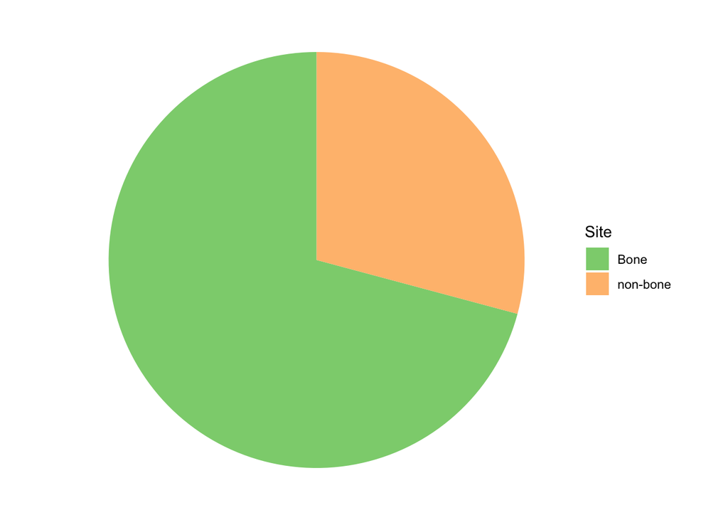

```r
dv1 <- df_tumor_p %>% filter(Visit == "V1") %>% group_by(Site) %>% count() %>%
  ungroup() %>%
  mutate(Per = round( n/sum(n) * 100) )

ggplot(dv1, aes(x="", y=n, fill=Site)) +
  geom_bar(stat="identity", width=1) +
  coord_polar("y", start=0) +
  theme_void() +
  scale_fill_manual(values=c("#8CD17D", "#FFBE7D")) +
  NULL
```

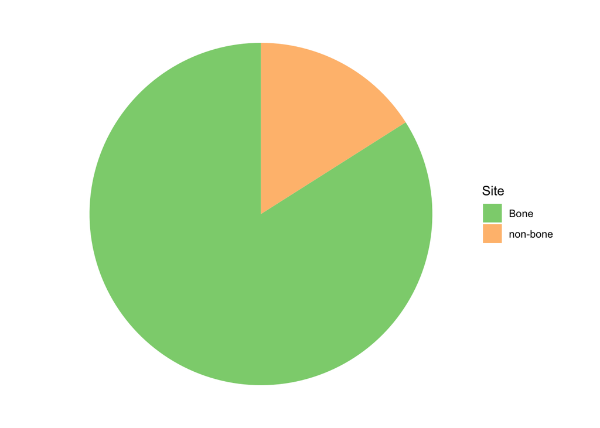

```r
ggsave(file=file.path(wd$output, "Site_V1_pie.pdf"), device = "pdf", width = 4, height = 4)

dv2 <- df_tumor_p %>% filter(Visit == "V2") %>% group_by(Site) %>% count() %>%
  ungroup() %>%
  mutate(Per = round( n/sum(n) * 100) )

ggplot(dv2, aes(x="", y=n, fill=Site)) +
  geom_bar(stat="identity", width=1) +
  coord_polar("y", start=0) +
  theme_void() +
  scale_fill_manual(values=c("#8CD17D", "#FFBE7D")) +
  NULL
```

```r
ggsave(file=file.path(wd$output, "Site_V2_pie.pdf"), device = "pdf", width = 4, height = 4)
```

# 5 Objective 2

**Read exome data CNA results**

The results of the CNA is in the file ‘.called.seg.xls’. Lets find all the results file.

```r
file_dir <- file.path(wd$data, "from_DavidNix/CNR_exome_analysis/pass_QC/")
ll <- list.files(file_dir, recursive = TRUE, full.names = TRUE)
# Only find the .xls file
ll2 <- ll[grep(".xls", ll)]
```

Read an example result

```r
df_eg <- read.delim(ll2[4])
```

The copy number call is in the ‘CR.Call’ column, while the list of genes in the ‘Genes’ column. We make it so that one gene have their approriate CR value.

```r
gg <- df_eg$Genes
gene_list <- str_split(gg, ",")
names(gene_list) <- paste0("cr_", df_eg$CR.Call)

pass_thresh <- df_eg$Pass.Thresholds
lg2CNR <-  df_eg$Lg2.Mean.TN.CR.Ratios

# Create data frame
# --- Genomic positions --- #
pos_id <- gsub(".*,", "", df_eg$X.Chr.Start.End)
pos_id <- gsub("\\)", "", pos_id)
head(pos_id)
```

```
## [1] "chr1:826293-1757809"    "chr1:1758005-1893159"   "chr1:1914383-6097019"
## [4] "chr1:6097020-6102472"   "chr1:6104602-10256884"  "chr1:10258046-10268678"
```

```r
chr_id <- gsub(":.*", "", pos_id)
head(chr_id)
```

```
## [1] "chr1" "chr1" "chr1" "chr1" "chr1" "chr1"
```

```r
srt_id <- gsub(".*:", "", pos_id)
srt_id <- as.numeric(gsub("-.*", "", srt_id))
head(srt_id)
```

```
## [1]   826293  1758005  1914383  6097020  6104602 10258046
```

```r
end_id <- gsub(".*:", "", pos_id)
end_id <- as.numeric(gsub(".*-", "", end_id))
head(end_id)
```

```
## [1]  1757809  1893159  6097019  6102472 10256884 10268678
```

```r
size_id <- end_id - srt_id

# --- Make DF --- #
df <- data.frame(
  loc = rep(paste0(chr_id, ":", srt_id, "-", end_id),lengths(gene_list)),
  size = rep(size_id,lengths(gene_list)),
  All_genes = rep(df_eg$Genes,lengths(gene_list)),
  cr = rep(names(gene_list), lengths(gene_list)),
  Genes = unlist(gene_list),
  pass_thresh = rep(pass_thresh, lengths(gene_list)),
  lg2CNR = rep(lg2CNR, lengths(gene_list))
) %>%
  # remove the "."
  filter(!Genes == ".")
```

```r
table(df$cr)
```

```
##
##  cr_-  cr_+  cr_0
## 11753 13702 12408
```

Now filter the df to the genes of interest

```r
df_sub <- df %>% filter(Genes %in% gene_panel)
```

Lets repeat for all samples, but we add an identifier for the sample name

```r
# Create an empty list to store the data frames
df_list <- list()

# First create a list containing all the results
for (i in seq_along(ll2)) {

  fileName <- basename(dirname(dirname(dirname(dirname(ll2[i])))))

  df_eg <- read.delim(ll2[i])

  gg <- df_eg$Genes
  gene_list <- str_split(gg, ",")
  names(gene_list) <- paste0("cr_", df_eg$CR.Call)

  pass_thresh <- df_eg$Pass.Thresholds
  lg2CNR <-  df_eg$Lg2.Mean.TN.CR.Ratios

# Create data frame
# --- Genomic positions --- #
pos_id <- gsub(".*,", "", df_eg$X.Chr.Start.End)
pos_id <- gsub("\\)", "", pos_id)
head(pos_id)

chr_id <- gsub(":.*", "", pos_id)
head(chr_id)

srt_id <- gsub(".*:", "", pos_id)
srt_id <- as.numeric(gsub("-.*", "", srt_id))
head(srt_id)

end_id <- gsub(".*:", "", pos_id)
end_id <- as.numeric(gsub(".*-", "", end_id))
head(end_id)

size_id <- end_id - srt_id

# --- Make DF --- #
df <- data.frame(
  file_name = fileName,
  loc = rep(paste0(chr_id, ":", srt_id, "-", end_id),lengths(gene_list)),
  size = rep(size_id,lengths(gene_list)),
  All_genes = rep(df_eg$Genes,lengths(gene_list)),
  cr = rep(names(gene_list), lengths(gene_list)),
  Genes = unlist(gene_list),
  pass_thresh = rep(pass_thresh, lengths(gene_list)),
  lg2CNR = rep(lg2CNR, lengths(gene_list))
) %>%
  # remove the "."
  filter(!Genes == ".")

  # Append the data frame to the list
  df_list <- c(df_list, list(df))
}
```

Combine the data frames into a single data frame

```r
combined_df <- bind_rows(df_list)
```

Filter to the genes of interest and make the CV call numeric

```r
conbined_df_sub <- combined_df %>% filter(Genes %in% gene_panel) %>%
  # Swap CR value to -1, 0, 1
  mutate(cr = case_when(cr == "cr_0" ~ 0,
                        cr == "cr_-" ~ -1,
                        cr == "cr_+" ~ 1
                        ))
```

Lets add the samples name according to the paper

```r
conbined_df_sub <- left_join(conbined_df_sub, df_join2)  %>%
  # Remove Exome runs not from paper
  filter(!is.na(PatientID))
```

Check samples number

```r
dplyr::filter(conbined_df_sub, visit == "V1") %>% pull(SubjectID) %>% unique() %>% length()
```

```
## [1] 68
```

```r
dplyr::filter(conbined_df_sub, visit == "V2") %>% pull(SubjectID) %>% unique() %>% length()
```

```
## [1] 74
```

# 6 Objective 3

**Set trehsold of CNA**

We set the threshold for calling CNA

```r
amp_thresh <- 0.5
del_thresh <- -0.5
```

Now we have the results of the exome CNR workflow. Lets determine the correlation

To start, we need to simplify the CNR calls. Because in the paper, Manish just classified the genes as either amplified or deleted Ie - a gene never has amplified and deleted, its always amplified or no change and alternatively deleted or no change. So we identify which genes are amplified genes and deleted genes.

```r
amp_genes <- df_gene %>% filter(Cat == "amp") %>% pull(Genes)
del_genes <- df_gene %>% filter(Cat == "del") %>% pull(Genes)
```

Simplify the call

```r
df_simple <- conbined_df_sub %>%
  mutate(cr = case_when(
    Genes %in% amp_genes & cr == -1 ~ 0,
    Genes %in% amp_genes & cr == 0 ~ 0,
    Genes %in% amp_genes & cr == 1 ~ 1,

    Genes %in% del_genes & cr == -1 ~ -1,
    Genes %in% del_genes & cr == 0 ~ 0,
    Genes %in% del_genes & cr == 1 ~ 0,
  ))

# Sanity check - a gene needs to have either 0 or -1 / 1
#table(df_simple$Genes, df_simple$cr)

# Save file
writexl::write_xlsx(df_simple, file.path(wd$output, "RawCNV_calls.xlsx"))
```

Lets convert the results to a gene x sample format. We need to separate visit 1 and visit 2.

```r
df_v1 <- df_simple %>% filter(visit == "V1") %>%
  select(Genes, PatientID, cr) %>%
  # Convert to wide format
  pivot_wider(names_from = PatientID, values_from = cr)
```

Here we face a problem. It appears that a gene has muliple copy number call. For example

```r
#combined_df %>% filter(file_name == "Nci_1622718_SRR4043829_SRR4043919_SRR4043972" & Genes == "AR")
```

The gene AR is called as amp and deleted This is odd.

So to overcome this, use an alternate workflow. Lets retain the genes with a “true” value, ie - the gene CV call passed a thresholding filter. Then we identify if based on this criteria, are there still genes with different CV calls.

```r
df_simple %>% filter(visit == "V1") %>%
  filter(pass_thresh == "true") %>%
  dplyr::group_by(Genes, SubjectID) %>%
  distinct() %>%
  dplyr::summarise(n = dplyr::n(), .groups = "drop") %>%
  dplyr::filter(n > 1L)
```

```
## # A tibble: 14 × 3
##    Genes   SubjectID     n
##    <chr>   <chr>     <int>
##  1 AR      S15           2
##  2 AR      S84           2
##  3 COL22A1 S11           2
##  4 COL22A1 S23           2
##  5 COL22A1 S34           2
##  6 COL22A1 S53           2
##  7 COL22A1 S62           2
##  8 MYC     S4            2
##  9 NOTCH1  S57           2
## 10 TMPRSS2 S21           2
## 11 TMPRSS2 S61           2
## 12 TMPRSS2 S78           2
## 13 TMPRSS2 S87           2
## 14 TP53    S75           2
```

```r
#df_simple %>% filter(SubjectID == "S11" & Genes == "COL22A1" & visit == "V1")
#combined_df  %>% filter(file_name == "Nci_1622764_SRR4043872_SRR4043934_SRR4043955" & Genes == "TMPRSS2")
```

Easy solution is to take the max for genes considered amplified. And min for genes considered deleted.

```r
df_simple2 <- df_simple %>%
  group_by(Genes, UniqID) %>%
  mutate(lg2CNR = case_when(Genes %in% amp_genes ~ max(lg2CNR),
                            Genes %in% del_genes ~ min(lg2CNR))) %>%
  distinct()
```

Apply filter for the cr calls

```r
df_simple2 <- df_simple2 %>%
   mutate(cr = case_when(
    Genes %in% amp_genes & lg2CNR >= amp_thresh ~ 1,
    Genes %in% del_genes & lg2CNR <= del_thresh~ -1,
    TRUE ~ 0
  )) %>%
  select(-pass_thresh) %>% distinct()
```

Lets try again

```r
df_simple2 %>% filter(visit == "V1") %>%
  #filter(pass_thresh == "true") %>%
  dplyr::group_by(Genes, SubjectID) %>%
  distinct() %>%
  dplyr::summarise(n = dplyr::n(), .groups = "drop") %>%
  dplyr::filter(n > 1L)
```

```
## # A tibble: 28 × 3
##    Genes   SubjectID     n
##    <chr>   <chr>     <int>
##  1 AR      S15           3
##  2 AR      S6            2
##  3 AR      S74           3
##  4 AR      S84           2
##  5 COL22A1 S11           2
##  6 COL22A1 S23           2
##  7 COL22A1 S25           2
##  8 COL22A1 S34           2
##  9 COL22A1 S53           2
## 10 COL22A1 S62           2
## # ℹ 18 more rows
```

```r
#df_simple2 %>% filter(SubjectID == "S15" & Genes == "AR" & visit == "V1")
```

One thing to check is the sample number. We know V1 visit has 68 samples.

```r
# Sample number of all files
kk <- df_simple2 %>% ungroup() %>%
  filter(visit == "V1")
length(unique(kk$PatientID))
```

```
## [1] 68
```

Even if a sample has no call made above the filter threshold, we still retain the samples

> Because we add ‘distinct’ while making df_simple2, this is not needed

```r
# The ones that pass the filter
kk2 <- df_simple2 %>% ungroup() %>%
  filter(visit == "V1") %>%
  filter(pass_thresh == "true") %>%
  dplyr::select(Genes, PatientID, cr) %>%
  distinct()
length(unique(kk$PatientID))
```

[output not shown]

We need to make it the same number of samples

```r
# Find missing samples
miss_samp <- kk %>% filter(!PatientID %in% kk2$PatientID) %>% pull(PatientID) %>% unique()

# Missing samples were given 0
tmp_df <- data.frame(
  Genes = "AR",
  PatientID = miss_samp,
  cr = 0
)

kk2 <- rbind(kk2, tmp_df)
```

Now generate a; gene x sample matrix.

```r
df_v1 <- df_simple2 %>%
  ungroup() %>%
  filter(visit == "V1") %>%
  #filter(pass_thresh == "true") %>%
  dplyr::select(Genes, PatientID, cr) %>%
  distinct() %>%
  # Convert to wide format, absent values is given 0
  pivot_wider(names_from = PatientID, values_from = cr, values_fill = 0)
```

Repeat for visit 2. Because we adjusted the treshold, we don’t get duplication. Otherwise we need to troubleshoot

Example scripts to troubleshoot (NOT run)

```r
df_simple2 %>% filter(visit == "V2") %>%
  filter(pass_thresh == "true") %>%
  dplyr::group_by(Genes, SubjectID) %>%
  distinct() %>%
  dplyr::summarise(n = dplyr::n(), .groups = "drop") %>%
  dplyr::filter(n > 1L)

df_simple %>% filter(SubjectID == "S74" & Genes == "AR" & visit == "V2")

df_simple %>% filter(Subject_ID == "S74" & Genes == "AR")
combined_df  %>% filter(file_name == "Mayo_1622777_SRR4043883_SRR21121521_SRR21121598" & Genes == "AR")

df_simple %>% filter(Subject_ID == "S63" & Genes == "NCOR1")
combined_df  %>% filter(file_name == "Mayo_1622766_SRR4043784_SRR21121542_SRR21121616" & Genes == "NCOR1")

# For now lets change these CN to just 0 because we are not sure
df_v2 <-
df_simple2 %>% ungroup() %>% filter(visit == "V2") %>%
  filter(pass_thresh == "true") %>%
  #filter(!Genes == "TMPRSS2") %>%
  dplyr::select(Genes, PatientID, cr, file_name) %>%
  distinct()

# Manually edith AR and NCOR in the respective patient %>%
df_v2 <- df_v2 %>%
  # mutate(cr =
  #          case_when(Genes == "AR" & file_name == "Mayo_1622777_SRR4043883_SRR21121521_SRR21121598" ~ 0,
  #                    Genes == "NCOR1" & file_name == "Mayo_1622766_SRR4043784_SRR21121542_SRR21121616" ~ 0,
  #                    TRUE ~ cr)) %>%
  dplyr::select(Genes, PatientID, cr) %>%
  distinct() %>%
  # Convert to wide format, absent values is given 0
  pivot_wider(names_from = PatientID, values_from = cr, values_fill = 0)
```

Make a gene x matrix (combine all steps above)

```r
# # Sample number of all files
# kk <- df_simple2 %>% ungroup() %>%
#   filter(visit == "V2")
# length(unique(kk$PatientID))
#
# # The ones that pass the filter
# kk2 <- df_simple2 %>% ungroup() %>%
#   filter(visit == "V2") %>%
#   filter(pass_thresh == "true") %>%
#   dplyr::select(Genes, PatientID, cr) %>%
#   distinct()
# length(unique(kk2$PatientID))
#
# # Find missing samples
# miss_samp <- kk %>% filter(!PatientID %in% kk2$PatientID) %>% pull(PatientID) %>% unique()
#
# # Missing samples were given 0
# tmp_df <- data.frame(
#   Genes = "AR",
#   PatientID = miss_samp,
#   cr = 0
# )
#
# kk2 <- rbind(kk2, tmp_df)

df_v2 <- df_simple2 %>%
  ungroup() %>%
  filter(visit == "V2") %>%
  #filter(pass_thresh == "true") %>%
  dplyr::select(Genes, PatientID, cr) %>%
  distinct() %>%
  # Convert to wide format, absent values is given 0
  # Convert to wide format, absent values is given 0
  pivot_wider(names_from = PatientID, values_from = cr, values_fill = 0)
```

# 7 Objective 4

**Comparison to public**

One question we had is how representative the CNR is compared to public data. So we download some data from cBioPortal and have a look at the frequency

We are just interested in Visit 1 for now.

> Current sample number is 68 - correct

```r
# Workflow to play around with threshold

tresh_cut <- c(0.1,0.2,0.3,0.4,0.5)

list_cut <- list()

for (i in seq_along(tresh_cut)){

amp_thresh <- tresh_cut[i]
del_thresh <- amp_thresh * -1

df_simple3 <- df_simple %>%
  group_by(Genes, UniqID) %>%
  mutate(lg2CNR = case_when(Genes %in% amp_genes ~ max(lg2CNR),
                            Genes %in% del_genes ~ min(lg2CNR))) %>%
  distinct()


df_simple3 <- df_simple3 %>%
  mutate(cr = case_when(
    Genes %in% amp_genes & lg2CNR >= amp_thresh ~ 1,
    Genes %in% del_genes & lg2CNR <= del_thresh~ 1,
    TRUE ~ 0
  )) %>%
  select(-pass_thresh) %>% distinct()

# Check if this runs
df_v1 <- df_simple3 %>%
  ungroup() %>%
  filter(visit == "V1") %>%
  #filter(pass_thresh == "true") %>%
  dplyr::select(Genes, PatientID, cr) %>%
  distinct() %>%
  # Convert to wide format, absent values is given 0
  pivot_wider(names_from = PatientID, values_from = cr, values_fill = 0)

cc <- rowSums(df_v1[,-1])
list_cut[[i]] <- cc
}
```

Compile list

```r
df_comp <- do.call(rbind, list_cut) %>% as.data.frame()
colnames(df_comp) <- df_v1$Genes
df_comp$Para <- c(paste0("t_", tresh_cut))
```

Get frequency in liquid

```r
# Visit 1
file_dir <- file.path(wd$data, "from_papers/cancers_2022_plasma/")
pap_v1 <- readxl::read_excel(file.path(file_dir, "Table S3.xlsx"),
                             sheet = 2)  %>%
  select(PatientID...1, AR, COL22A1, MYC, NCOR1, NKX3.1, NOTCH1, PIK3CA, PIK3CB, TP53, ZBTB16, TMPRSS2) %>%
  mutate(across(AR:TMPRSS2, ~ case_when(
    . == "NC" ~ 0,
    . == "Amp" ~ 1,
    . == "Del" ~ -1))) %>% as.data.frame()
row.names(pap_v1) <- pap_v1$PatientID...1
pap_v1 <- pap_v1[,-1]
pap_v1 <- t(pap_v1)
row.names(pap_v1) <- gsub("NKX3.1", "NKX3-1", row.names(pap_v1))

# Calculate percentage of alteration
ss <- colnames(df_v1)[-1] # Same sample as in exome
# Same gene order, so we can simply r bind later
pap_v1 <- pap_v1[,ss]
perc_cn <- apply(abs(pap_v1), 1, sum)  %>% as.data.frame() %>% t() %>% as.data.frame()
perc_cn$Para  <- "liq"
perc_cn <- perc_cn[,colnames(df_comp)]
```

Combine all into one for plotting

```r
df_freq <- rbind(df_comp, perc_cn)
m <- melt(df_freq) %>%
  mutate(Perc = value / length(ss) * 100,
         Type = case_when(variable %in% amp_genes ~ "Amp",
                            variable %in% del_genes ~ "Del"))
```

```r
m_or <- m %>% filter(Para == "liq") %>% arrange(Type, desc(Perc))

m <- m %>% mutate(variable = factor(variable, levels=m_or$variable))

m1 <- m %>% filter(Type == "Amp")
p1 <-
  ggplot(m1, aes(x=Para, y=Perc, fill=Para)) +
  geom_bar(stat = "identity", position = position_dodge2(preserve = "single")) +
  facet_grid(~variable) +
  theme_bw() +
    theme(legend.position = "bottom",
          panel.grid.major = element_line(linetype = "blank"),
          panel.grid.minor = element_line(linetype = "blank")) +
  scale_fill_manual(values = c("brown", viridis::cividis(5))) +
  NULL

m2 <- m %>% filter(Type == "Del")
p2<-
  ggplot(m2, aes(x=Para, y=Perc, fill=Para)) +
  geom_bar(stat = "identity", position = position_dodge2(preserve = "single")) +
  facet_grid(~variable) +
  theme_bw() +
    theme(legend.position = "bottom",
          panel.grid.major = element_line(linetype = "blank"),
          panel.grid.minor = element_line(linetype = "blank")) +
  scale_fill_manual(values = c("brown", viridis::cividis(5))) +
  NULL

mm <- p1 / p2

ggsave(mm, file=file.path(wd$output, "Treshold_range.pdf"), device = "pdf", width = 9, height = 6)
```

Get some CNA from public database

```r
d1 <- read.delim(file.path(wd$data, "public_data/CNA_Genes_Metastatic_castration-sensitive_prostate_cancer_MSK.txt")) %>%
  #filter(Gene %in% df_gene$Genes) %>%
  filter(Gene %in% amp_genes & CNA == "AMP" |
           Gene %in% del_genes & CNA == "HOMDEL") %>%
  mutate(Study = "D1")

d2 <- read.delim(file.path(wd$data, "public_data/CNA_Genes_Metastatic_Prostate_Adenocarcinoma_MCTP.txt")) %>%
  filter(Gene %in% amp_genes & CNA == "AMP" |
           Gene %in% del_genes & CNA == "HOMDEL") %>%
  mutate(Study = "D2")

# d3 <- read.delim(file.path(wd$data, "public_data/CNA_Genes_Metastatic_Prostate_Adenocarcinoma_SU2C_PCF_PNAS_2019.txt")) %>%
#   filter(Gene %in% amp_genes & CNA == "AMP" |
#            Gene %in% del_genes & CNA == "HOMDEL") %>%
#   mutate(Study = "D3")

d4 <- read.delim(file.path(wd$data, "public_data/CNA_Genes_The_Metastatic_Prostate_Cancer_Project.txt")) %>%
  filter(Gene %in% amp_genes & CNA == "AMP" |
           Gene %in% del_genes & CNA == "HOMDEL") %>%
  mutate(Study = "D4")

d5.1 <- read.delim(file.path(wd$data, "public_data/CNA_Genes_Metastatic_Prostate_Adenocarcinoma_SU2C_PCF_Cell_2015.txt")) %>%
  filter(Gene %in% amp_genes & CNA == "AMP" |
           Gene %in% del_genes & CNA == "HOMDEL") %>%
  mutate(Study = "D5.all")

# d5.2 <- read.delim(file.path(wd$data, "public_data/CNA_Genes_Metastatic_Prostate_Adenocarcinoma_SU2C_PCF_Cell_2015_preTreatment.txt")) %>%
#   filter(Gene %in% amp_genes & CNA == "AMP" |
#            Gene %in% del_genes & CNA == "HOMDEL") %>%
#   mutate(Study = "D5.pre")

d6 <- read.delim(file.path(wd$data, "public_data/CNA_Genes_Metastatic_Prostate_Adenocarcinoma_SU2C_PCF_PNAS_2019.txt")) %>%
  filter(Gene %in% amp_genes & CNA == "AMP" |
           Gene %in% del_genes & CNA == "HOMDEL") %>%
  mutate(Study = "D6")
```

For the SU2C paper, we also wanted to get the frequency of the Naive samples. We do the script once to get the patients id so that we can put into cBioPortal.

```r
# Where we manually select the pre-treatment
# We extracted the metadata from the supplemntary table of the original publication - https://www.ncbi.nlm.nih.gov/pubmed/31061129
d6_pub <- read_xlsx(file.path(wd$data, "public_data/pnas.1902651116.sd01_filtered.xlsx")) %>%
  # Filter to Adrenocarcioma samples and treatment Naive
  filter(`Pathology Classification` == "Adenocarcinoma" &
           `Abiraterone (ABI) and Enzalutamide (ENZA) Exposure Status` == "Naive" &
           `Taxane exposure status` == "Naïve")

# All 444 samples from cBioPortal
d6_sub <- read_xlsx(file.path(wd$data, "public_data/cBioPortal_prostate/02_prad_su2c_2019_clinical_data.xlsx"))  %>%
  # Subset
  filter(`Patient ID` %in% d6_pub$`Subject ID`) %>%
  filter(`Abiraterone (ABI) and Enzalutamide (ENZA) Exposure Status` == "Naive") %>%
  # Add column to be used in cBioPortal
  mutate(Study_Sample_ID = paste(`Study ID`, `Sample ID`, sep= ":"))

writexl::write_xlsx(d6_sub, file.path(wd$output, "PNAS_2019_Naive.xlsx"))
```

Once we get the patient IDs, we then query cBioPortal only for these patients

```r
# d5.1 <- read.delim(file.path(wd$data, "public_data/CNA_Genes_Metastatic_Prostate_Adenocarcinoma_SU2C_PCF_Cell_2015.txt")) %>%
#   filter(Gene %in% amp_genes & CNA == "AMP" |
#            Gene %in% del_genes & CNA == "HOMDEL") %>%
#   mutate(Study = "D5.all")

d6.1 <- read.delim(file.path(wd$data, "public_data/CNA_Genes_Metastatic_Prostate_Adenocarcinoma_SU2C_PCF_PNAS_2019_naive.txt")) %>%
  filter(Gene %in% amp_genes & CNA == "AMP" |
           Gene %in% del_genes & CNA == "HOMDEL") %>%
  mutate(Study = "D6.1")



d_all <- rbind(d1,d2,d4, d5.1, d6, d6.1) %>%
  mutate(Perc = gsub("%", "", Freq),
         Perc = as.numeric(Perc),
         Type = case_when(CNA == "HOMDEL" ~ "Del",
                          CNA == "AMP" ~ "Amp")) %>%
  select(Gene, Type, Perc, Study)

m_pub <- data.frame(
  Para = d_all$Study,
  variable = d_all$Gene,
  Perc = d_all$Perc,
  Type = d_all$Type
)

m_tmp <- m %>% select(-value)

m_all <- rbind(m_tmp, m_pub) #%>% filter(!Para == "liq")

# Add seperator
t_no <- data.frame(
  Para = c("D7", "m1"),
  variable = rep(c("MYC", "TP53"),each=2),
  Perc = 0,
  Type = rep(c("Amp", "Del"),each=2)
)

m_all <- rbind(m_all, t_no)

# We are not interested in liquid
m_all <- m_all %>% filter(!Para == "liq")

# Rearrange the order
x_or <- c("t_0.1", "t_0.2", "t_0.3", "t_0.4", "t_0.5",
          #"D7","liq", "m1",
          "D7", "m1",
          "D1", "D2", "D4", "D5.all", "D6", "D6.1")
g_or <- m_all %>% filter(Para == "t_0.5")
g_or1 <- g_or %>% filter(Type == "Amp") %>% arrange(Perc) %>% pull(variable)
g_or2 <- g_or %>% filter(Type == "Del") %>% arrange(Perc) %>% pull(variable)

m_all <- m_all %>%
  mutate(Para = factor(Para, levels=x_or),
         variable = factor(variable, levels=c(g_or1, g_or2)))

col.bar <- c(#"#05215DFF", "#BFC8D3FF", "#E63833FF", "#5E9546FF",
             #"#8A8CA4FF", #"#D3EEF9FF",
  paletteer::paletteer_c('viridis::viridis', 5 ),
  "white",
  #"red",
  "white",
  "#5495CFFF", "#F5AF4DFF", "#847CA3FF", "#7C873EFF", "#B8396BFF", "#FFD1D7FF")




m1 <- m_all %>% filter(Type == "Amp") %>% filter(!variable == "TP53") %>%
  mutate(lab = paste0(round(Perc,0), "%"))
p1 <-
  ggplot(m1, aes(x=Para, y=Perc, fill=Para)) +
  geom_bar(stat = "identity", position = position_dodge2(preserve = "single")) +
  facet_wrap(~variable, ncol=3) +
  theme_bw() +
    theme(legend.position = "none",
          panel.grid.major = element_line(linetype = "blank"),
          panel.grid.minor = element_line(linetype = "blank"),
          #axis.text.x = element_blank(),
          ) +
  geom_text(aes(label=lab, vjust=-.5), size=2.5) +
  scale_fill_manual(values=col.bar) +
  NULL

m2 <- m_all %>% filter(Type == "Del") %>% #filter(!variable == "MYC")
  mutate(lab = paste0(round(Perc,0), "%"))
p2<-
  ggplot(m2, aes(x=Para, y=Perc, fill=Para)) +
  geom_bar(stat = "identity", position = position_dodge2(preserve = "single")) +
  facet_wrap(~variable, ncol=3) +
  theme_bw() +
    theme(legend.position = "bottom",
          panel.grid.major = element_line(linetype = "blank"),
          panel.grid.minor = element_line(linetype = "blank")) +
  geom_text(aes(label=lab, vjust=-.5), size=2.5) +
  scale_fill_manual(values=col.bar) +
  NULL

mm <- p1 / p2

ggsave(mm, file=file.path(wd$output, "Treshold_public_DB_v2.pdf"), device = "pdf", width = 12, height = 9)
```

## 7.1 In treatment naive

We get the percentages of each gene alteration in treatement naive

```r
dat_cn <- read.delim(file.path(wd$data, "public_data/cBioPortal_prostate/cna.txt"))


d1 <- read.delim(file.path(wd$data, "public_data/cBioPortal_prostate/01_CNA_Genes.txt")) %>%
  #filter(Gene %in% df_gene$Genes) %>%
  filter(Gene %in% amp_genes & CNA == "AMP" |
           Gene %in% del_genes & CNA == "HOMDEL") %>%
  mutate(Study = "D1")

d2 <- read.delim(file.path(wd$data, "public_data/cBioPortal_prostate/02_CNA_Genes.txt")) %>%
  #filter(Gene %in% df_gene$Genes) %>%
  filter(Gene %in% amp_genes & CNA == "AMP" |
           Gene %in% del_genes & CNA == "HOMDEL") %>%
  mutate(Study = "D2")


d3 <- read.delim(file.path(wd$data, "public_data/cBioPortal_prostate/03_CNA_Genes.txt")) %>%
  #filter(Gene %in% df_gene$Genes) %>%
  filter(Gene %in% amp_genes & CNA == "AMP" |
           Gene %in% del_genes & CNA == "HOMDEL") %>%
  mutate(Study = "D3")






d_all <- rbind(d1,d2,d3) %>%
  mutate(Perc = gsub("%", "", Freq),
         Perc = as.numeric(Perc),
         Type = case_when(CNA == "HOMDEL" ~ "Del",
                          CNA == "AMP" ~ "Amp")) %>%
  select(Gene, Type, Perc, Study)

m_pub <- data.frame(
  Para = d_all$Study,
  variable = d_all$Gene,
  Perc = d_all$Perc,
  Type = d_all$Type
)



p1 <-
  ggplot(m_pub, aes(x=Para, y=Perc, fill=Para)) +
  geom_bar(stat = "identity", position = position_dodge2(preserve = "single")) +
  facet_wrap(Type~variable, ncol=6) +
  theme_bw() +
  theme(legend.position = "none",
        panel.grid.major = element_line(linetype = "blank"),
        panel.grid.minor = element_line(linetype = "blank"),
        #axis.text.x = element_blank(),
  ) +
  geom_text(aes(label=round(Perc,0)), vjust=0) +
  scale_fill_manual(values=col.bar) +
  NULL
p1
```

[output not shown]

## 7.2 Pie chart

For one of the publication generat a pie-chart as well

```r
# Where we manually select the pre-treatment
# We extracted the metadata from the supplemntary table of the original publication - https://www.ncbi.nlm.nih.gov/pubmed/31061129
d6_pub <- read_xlsx(file.path(wd$data, "public_data/pnas.1902651116.sd01_filtered.xlsx")) %>%
  rename(Sample_ID = 'Sample ID',
         Sample_type = 'Sample Type')

d6_pub_naive <- d6_pub %>%
  # Filter to Adrenocarcioma samples and treatment Naive
  filter(#`Pathology Classification` == "Adenocarcinoma" &
           `Abiraterone (ABI) and Enzalutamide (ENZA) Exposure Status` == "Naive" &
           `Taxane exposure status` == "Naïve")


d6_pub_not_naive <- d6_pub %>%
  filter(!Sample_ID %in% d6_pub_naive$Sample_ID)
```

Simple pie chart of the number of samples

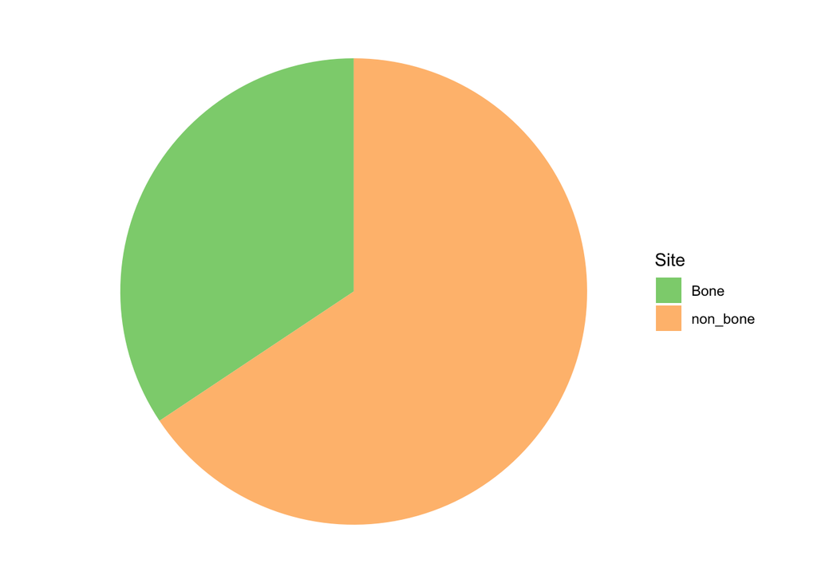

```r
dv1 <- d6_pub_naive %>%
  mutate(Site = case_when(!Sample_type == "Bone" ~ "non_bone",
                          TRUE ~ Sample_type)) %>%
  group_by(Site) %>% count() %>%
  ungroup() %>%
  mutate(Per = round( n/sum(n) * 100) )

ggplot(dv1, aes(x="", y=n, fill=Site)) +
  geom_bar(stat="identity", width=1) +
  coord_polar("y", start=0) +
  theme_void() +
  scale_fill_manual(values=c("#8CD17D", "#FFBE7D")) +
  NULL
```

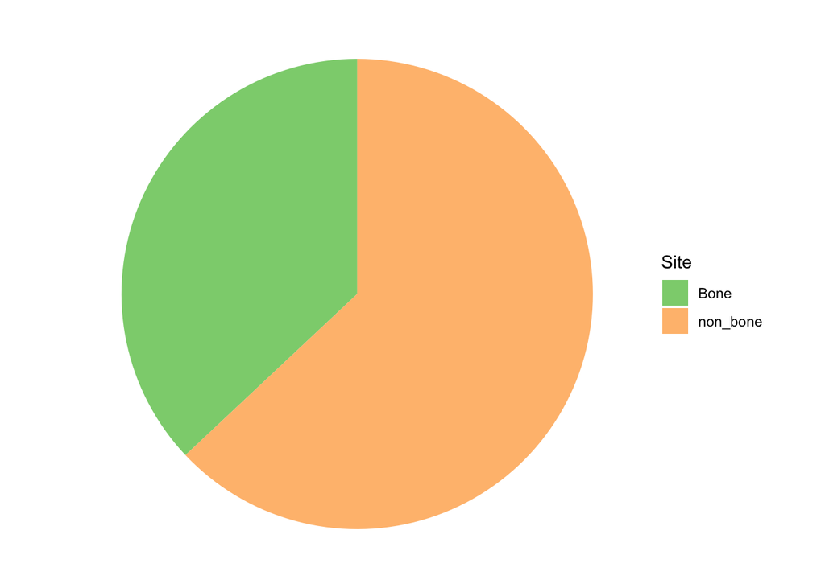

```r
ggsave(file=file.path(wd$output, "CBio_Site_pre_pie.pdf"), device = "pdf", width = 4, height = 4)

dv2 <- d6_pub_not_naive %>%
    mutate(Site = case_when(!Sample_type == "Bone" ~ "non_bone",
                          TRUE ~ Sample_type)) %>%
  group_by(Site) %>% count() %>%
  ungroup() %>%
  mutate(Per = round( n/sum(n) * 100) )

ggplot(dv2, aes(x="", y=n, fill=Site)) +
  geom_bar(stat="identity", width=1) +
  coord_polar("y", start=0) +
  theme_void() +
  scale_fill_manual(values=c("#8CD17D", "#FFBE7D")) +
  NULL
```

```r
ggsave(file=file.path(wd$output, "CBio_Site_post_pie.pdf"), device = "pdf", width = 4, height = 4)
```

# 8 Objective 5

Generate correlation between the number of genes called gain or loss with DNA purity and ctDNA content.

Modified to include all samples

```r
# Get call
df_simple2 <- df_simple %>%
  group_by(Genes, UniqID) %>%
  mutate(lg2CNR = case_when(Genes %in% amp_genes ~ max(lg2CNR),
                            Genes %in% del_genes ~ min(lg2CNR))) %>%
  distinct()


df_simple2 <- df_simple2 %>%
  mutate(cr = case_when(
    Genes %in% amp_genes & lg2CNR >= amp_thresh ~ 1,
    Genes %in% del_genes & lg2CNR <= del_thresh ~ 1,
    TRUE ~ 0
  )) %>%
  select(-pass_thresh) %>% distinct()

# Check if this runs
df_v1 <- df_simple2 %>%
  ungroup() %>%
  filter(visit == "V1") %>%
  #filter(pass_thresh == "true") %>%
  dplyr::select(Genes, PatientID, cr) %>%
  distinct() %>%
  # Convert to wide format, absent values is given 0
  pivot_wider(names_from = PatientID, values_from = cr, values_fill = 0)

# Running on all samples
df_v1 <- df_simple2 %>%
  ungroup() %>%
  #filter(visit == "V1") %>%
  #filter(pass_thresh == "true") %>%
  dplyr::select(Genes, PatientID, cr) %>%
  distinct() %>%
  # Convert to wide format, absent values is given 0
  pivot_wider(names_from = PatientID, values_from = cr, values_fill = 0)


sum_solid <- as.data.frame(colSums(df_v1[,-1]))
colnames(sum_solid) <- "NumGene"
sum_solid$PatientID <- rownames(sum_solid)
```

Combine with meta data of tumor purity.

```r
df_p <- df_tumor_p2 %>%
  left_join(sum_solid) %>%
  #left_join(sum_solid_amp) %>%
  #left_join(sum_solid_del) %>%
  mutate(Tumor_cut = case_when(Tumor_content <=10 ~ "low",
                               TRUE ~ "high"))
```

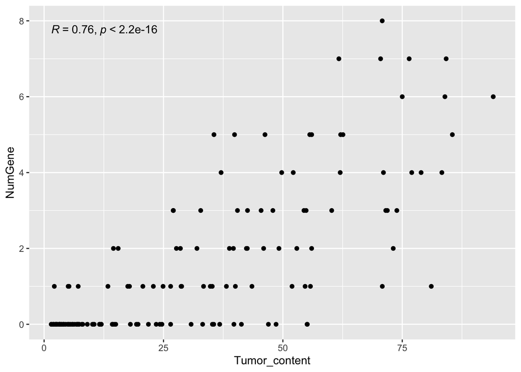

```r
ggplot(df_p, aes(x=Tumor_content, y=NumGene)) +
  geom_point() +
  stat_cor(method = "pearson")
```

```r
sp1.1 <-
  df_p %>% filter(Site == "Bone") %>%
  ggscatter(x = "Tumor_content", y = "NumGene",
   add = "reg.line",  # Add regressin line
   #facet.by = "Body_Site",
   #color = "Tumor_cut",
   add.params = list(color = "#8CD17D", fill = "lightgray"), # Customize reg. line
   conf.int = TRUE # Add confidence interval
   )  +
  geom_vline(xintercept = 20, linetype="dashed") +
  scale_x_continuous(limits=c(0,100), breaks=c(0,20,40,60,80, 100)) +
  scale_y_continuous(limits=c(0,9), breaks=c(0,2,4,6,8)) +
  stat_cor(method = "pearson") +
  ggtitle("Correlation in Solid, bone")


sp1.2 <-
  df_p %>% filter(Site == "non-bone") %>%
  ggscatter(x = "Tumor_content", y = "NumGene",
   add = "reg.line",  # Add regressin line
   #facet.by = "Body_Site",
   #color = "Tumor_cut",
   add.params = list(color = "#FFBE7D", fill = "lightgray"), # Customize reg. line
   conf.int = TRUE # Add confidence interval
   )  +
  geom_vline(xintercept = 20, linetype="dashed") +
  scale_x_continuous(limits=c(0,100), breaks=c(0,20,40,60,80, 100)) +
  scale_y_continuous(limits=c(0,9), breaks=c(0,2,4,6,8)) +
  stat_cor(method = "pearson") +
  ggtitle("Correlation in Solid, non-bone")
```

Combine with meta data of ct DNA fraction.

```r
# Visit 1
file_dir <- file.path(wd$data, "from_papers/cancers_2022_plasma/")
pap_v1 <- readxl::read_excel(file.path(file_dir, "Table S3.xlsx"),
                             sheet = 2)  %>%
  select(PatientID...1, AR, COL22A1, MYC, NCOR1, NKX3.1, NOTCH1, PIK3CA, PIK3CB, TP53, ZBTB16, TMPRSS2) %>%
  mutate(across(AR:TMPRSS2, ~ case_when(
    . == "NC" ~ 0,
    . == "Amp" ~ 1,
    . == "Del" ~ 1))) %>% as.data.frame()
row.names(pap_v1) <- pap_v1$PatientID...1
pap_v1 <- pap_v1[,-1]
pap_v1 <- t(pap_v1)
row.names(pap_v1) <- gsub("NKX3.1", "NKX3-1", row.names(pap_v1))

sum_liquid <- as.data.frame(colSums(pap_v1))
colnames(sum_liquid) <- "NumGene"
sum_liquid$PatientID <- rownames(sum_liquid)

# Visit 2
file_dir <- file.path(wd$data, "from_papers/cancers_2022_plasma/")
pap_v1 <- readxl::read_excel(file.path(file_dir, "Table S3.xlsx"),
                             sheet = 3)  %>%
  select(PatientID...1, AR, COL22A1, MYC, NCOR1, NKX3.1, NOTCH1, PIK3CA, PIK3CB, TP53, ZBTB16, TMPRSS2) %>%
  mutate(across(AR:TMPRSS2, ~ case_when(
    . == "NC" ~ 0,
    . == "Amp" ~ 1,
    . == "Del" ~ 1))) %>% as.data.frame()
row.names(pap_v1) <- pap_v1$PatientID...1
pap_v1 <- pap_v1[,-1]
pap_v1 <- t(pap_v1)
row.names(pap_v1) <- gsub("NKX3.1", "NKX3-1", row.names(pap_v1))

sum_liquid_v2 <- as.data.frame(colSums(pap_v1))
colnames(sum_liquid_v2) <- "NumGene"
sum_liquid_v2$PatientID <- rownames(sum_liquid_v2)

# Combine
sum_liquid_all <- rbind(sum_liquid, sum_liquid_v2)


df_l <- df_tumor_p3 %>% left_join(sum_liquid_all)

sp2 <- ggscatter(df_l, x = "ctDNA", y = "NumGene",
   add = "reg.line",  # Add regressin line
   add.params = list(color = "#A53D3C", fill = "lightgray"), # Customize reg. line
   conf.int = TRUE # Add confidence interval
   )  +
  geom_vline(xintercept = ct_cutoff, linetype="dashed") +
  stat_cor(method = "pearson") +
  #facet_wrap(~Visit, ncol=1) +
  ggtitle("Correlation in liquid")

ggsave(sp2, file=file.path(wd$output, "Correlation_with_ctDNA.pdf"), device = "pdf", width = 7, height = 2.5)
```

Save the plots

```r
pp <- sp1.1 / sp1.2

ggsave(pp, file=file.path(wd$output, "Correlation_with_DNA_3.pdf"), device = "pdf", width = 8, height = 4.5)
```

# 9 Save output

Save the copy number raw values, and simplified calls.

First get how the genes are ordered, from most frequent to least frequent

```r
# Workflow to play around with threshold
amp_thresh <- 0.5
del_thresh <- -0.5

df_simple2 <- df_simple %>%
  group_by(Genes, UniqID) %>%
  mutate(lg2CNR = case_when(Genes %in% amp_genes ~ max(lg2CNR),
                            Genes %in% del_genes ~ min(lg2CNR))) %>%
  distinct()


df_simple2 <- df_simple2 %>%
  mutate(cr = case_when(
    Genes %in% amp_genes & lg2CNR >= amp_thresh ~ 1,
    Genes %in% del_genes & lg2CNR <= del_thresh~ -1,
    TRUE ~ 0
  )) %>%
  select(-pass_thresh) %>% distinct()

# Check if this runs
df_v1 <- df_simple2 %>%
  ungroup() %>%
  filter(visit == "V1") %>%
  #filter(pass_thresh == "true") %>%
  dplyr::select(Genes, PatientID, cr) %>%
  distinct() %>%
  # Convert to wide format, absent values is given 0
  pivot_wider(names_from = PatientID, values_from = cr, values_fill = 0)

mat_v1 <- df_v1 %>% as.data.frame()
row.names(mat_v1) <- df_v1$Genes
mat_v1 <- mat_v1[,-1] %>% as.matrix()

#Heatmap(mat_v1)

gene_or <- sort(apply(mat_v1, 1, sum)) %>% names() %>% rev()
```

Now lets save the output

```r
df_simple2 <- df_simple %>%
  group_by(Genes, UniqID) %>%
  mutate(lg2CNR = case_when(Genes %in% amp_genes ~ max(lg2CNR),
                            Genes %in% del_genes ~ min(lg2CNR))) %>%
  distinct()


# --- Save the raw CNV value
df_simple_raw <- df_simple2 %>%
  select(-pass_thresh) %>% distinct() %>%
  ungroup() %>%
  filter(visit == "V1") %>%
  dplyr::select(Genes, PatientID, lg2CNR) %>%
  distinct() %>%
  # Convert to wide format, absent values is given 0
  pivot_wider(names_from = PatientID, values_from = lg2CNR) %>%
  mutate(Genes = factor(Genes, levels=gene_or)) %>%
  arrange(Genes)

write.csv(df_simple_raw, file.path(wd$output, "CNR_visit_1_raw.csv"))

df_simple_raw <- df_simple2 %>%
  select(-pass_thresh) %>% distinct() %>%
  ungroup() %>%
  filter(visit == "V2") %>%
  dplyr::select(Genes, PatientID, lg2CNR) %>%
  distinct() %>%
  # Convert to wide format, absent values is given 0
  pivot_wider(names_from = PatientID, values_from = lg2CNR) %>%
  mutate(Genes = factor(Genes, levels=gene_or)) %>%
  arrange(Genes)

write.csv(df_simple_raw, file.path(wd$output, "CNR_visit_2_raw.csv"))


# ---- Save the binary CN value

df_simple2 <- df_simple2 %>%
  mutate(cr = case_when(
    Genes %in% amp_genes & lg2CNR >= amp_thresh ~ 1,
    Genes %in% del_genes & lg2CNR <= del_thresh~ -1,
    TRUE ~ 0
  )) %>%
  select(-pass_thresh) %>% distinct()

# Check if this runs
df_simple_bin <- df_simple2 %>%
  ungroup() %>%
  filter(visit == "V1") %>%
  #filter(pass_thresh == "true") %>%
  dplyr::select(Genes, PatientID, cr) %>%
  distinct() %>%
  # Convert to wide format, absent values is given 0
  pivot_wider(names_from = PatientID, values_from = cr, values_fill = 0) %>%
  mutate(Genes = factor(Genes, levels=gene_or)) %>%
  arrange(Genes)

write.csv(df_simple_bin, file.path(wd$output, "CNR_visit_1_bin.csv"))


df_simple_bin <- df_simple2 %>%
  ungroup() %>%
  filter(visit == "V2") %>%
  #filter(pass_thresh == "true") %>%
  dplyr::select(Genes, PatientID, cr) %>%
  distinct() %>%
  # Convert to wide format, absent values is given 0
  pivot_wider(names_from = PatientID, values_from = cr, values_fill = 0) %>%
  mutate(Genes = factor(Genes, levels=gene_or)) %>%
  arrange(Genes)

write.csv(df_simple_bin, file.path(wd$output, "CNR_visit_2_bin.csv"))
```

## 9.1 Save objects

Save objects for future analysis

```r
#save.image(file.path(wd$outputData, "Section_01.Rdata"))

save(df_simple, wd, df_link2, df_tumor_p3, meta_l, gene_or,
     file = file.path(wd$outputData, "Section_01.RData"))
```